# Making Use of Machine Learning Resources from Python

Alexander Murray-Watters

April 9, 2019

# Why Python? Isn’t this an R course?

It’d be great if you only had to use a single programming language, but unfortunately that’s not the way the world works. While most new statistical methods are initially implemented for R (as their creators are statisticians), machine learning algorithms are usually created by computer scientists, who have built their own data analysis tool set around Python. While the algorithms are often ported to R (this is especially easy when Python was simply used as a convenient “wrapper” for the implementation), there is often a delay, and the quality of the R implementation can be very poor.

# Installing Python

Go to https://www.python.org/ and download the latest version. Then run the installer, choosing the defaults.

Install the `reticulate` package so that you can call python from R.

```r
##install.packages("reticulate")
```

Load the `reticulate` package.

```r
library(reticulate)
library(ggplot2)
```

# Calling python from R using reticulate

```r
## Importing the math library from python
math.main <- import("math")

## We access functions from the imported python library using the \$
## operator.

## Square root can take integers.
math.main$sqrt(4)
```

```
## [1] 2
```

```r
## Square root can take decimal numbers.
math.main$sqrt(4.2)
```

```
## [1] 2.04939
```

```r
## Log is base e.
math.main$log(math.main$e)
```

```
## [1] 1
```

```r
## Base 10 log.
math.main$log10(10)
```

```
## [1] 1
```

## The minimum you need to be aware of

Python, just like R, has different kinds of objects. Some commonly used ones are:

1. Integers (1, 2, 3, 4,…)
2. Decimal (.34234, .123, pi) (Called “numeric” in R, “floats” in Python).
3. DataFrame (from the pandas library in R).
4. Array (called a matrix in R).
5. Series (called a vector in R).

There are many other kinds of objects (and you can create your own). The relevant point for using reticulate is that you need to make sure the kind of object you are using in R is being converted to the right kind of object for the python function you are trying to make use of.

If a function in python requires an integer, you can’t simply pass it a number from R, as R defaults to using “numeric” objects to represent numbers. You have to convert the “numeric” to an “integer” first.

```r
a.number <- 1

class(a.number)
```

```
## [1] "numeric"
```

```r
class(as.integer(a.number))
```

```
## [1] "integer"
```

# An example using HDBSCAN

## The R version (from dbscan package)

```r
## cluster the moons data set with HDBSCAN

library(dbscan)

data(moons)
res <- dbscan::hdbscan(moons, minPts = 5)

res
```

```
## HDBSCAN clustering for 100 objects.
## Parameters: minPts = 5
## The clustering contains 3 cluster(s) and 0 noise points.
##
##  1  2  3
## 25 25 50
##
## Available fields: cluster, minPts, cluster_scores,
##                   membership_prob, outlier_scores, hc
```

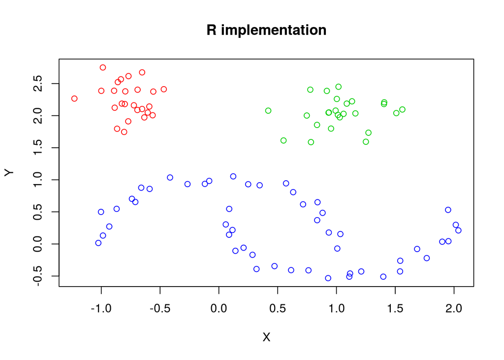

```r
plot(moons, col = res$cluster + 1, main="R implementation")
```

## Python version.

As the python version runs significantly faster (and uses less memory), you may want to go to the hassle of using it instead of the R implementation.

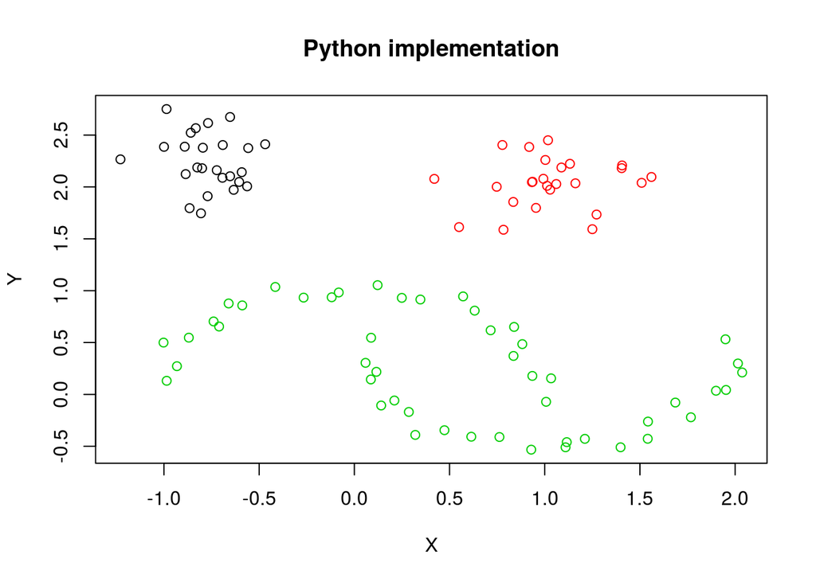

```r
library(reticulate)

hdbscan.main <- import("hdbscan")

hdbscan.py <- function(data, minPts){
    hdbscan.main$HDBSCAN(min_cluster_size=as.integer(minPts))$fit_predict(data)
}


clust.assignment <- hdbscan.py(data=as.matrix(moons), minPts=5)

plot(moons, col = clust.assignment + 1, main="Python implementation")
```

# An example using UMAP

Other algorithms are often too new to have mature R implementations. One of the more exciting examples of this is a non-linear dimension reduction technique called UMAP. While at least one R version exists, it is significantly slower and more resource intensive than the python implementation. The python version is also constantly receiving updates, as it is the main focus of the originator of the algorithm.

```r
umap.main <- import("umap")

## New version using reticulate.
umap <- function(x, n_neighbors = 10, min_dist = 0.1,
                 metric = 'euclidean', y = c(),
                 n_components = 2, ...){

    ## Have to convert in order to ensure reticulate gives
    ## UMAP the right kind of python objects.
    data <- as.matrix(x)
    n_neighbors <- as.integer(n_neighbors)
    n_components <- as.integer(n_components)

    ## Intializing umap object with var. parameters.
    umap.obj <- umap.main$UMAP(n_neighbors = n_neighbors,
                               min_dist = min_dist,
                               metric = metric,
                               n_components = n_components,
                               ...)

    return(umap.obj$fit_transform(data, y = y))
}

## Generating fake standard normal data.

fake.data <- cbind(rnorm(n=100), rnorm(n=100), rnorm(n=100))

head(fake.data)
```

```
##            [,1]       [,2]       [,3]
## [1,]  0.3668226 -0.7254786 -1.1328782
## [2,]  0.1960939 -1.0211586 -0.8834205
## [3,] -2.5401887 -0.9270511 -0.2783815
## [4,] -0.8766682 -0.4777409 -0.5509484
## [5,]  0.5540680 -0.9389408  1.1012426
## [6,] -0.8663174  1.0768516  0.6151648
```

```r
## Performing reduction.

dim.reduct <- umap(fake.data, n_neighbors = 15, min_dist = 0, metric = "euclidean", n_components = 1)

head(dim.reduct)
```

```
##            [,1]
## [1,] -6.0830188
## [2,] -6.1228194
## [3,]  5.6061935
## [4,]  5.4360700
## [5,]  1.7795700
## [6,]  0.1542731
```

### A more interesting example involving cars

Using the built in `mtcars` dataset, we can see how the method performs (in contrast to say, PCA).

```
 A data frame with 32 observations on 11 (numeric) variables.

   1  mpg   Miles/(US) gallon
   2  cyl   Number of cylinders
   3  disp  Displacement (cu.in.)
   4  hp    Gross horsepower
   5  drat  Rear axle ratio
   6  wt    Weight (1000 lbs)
   7  qsec  1/4 mile time
   8  vs    Engine (0 = V-shaped, 1 = straight)
   9  am    Transmission (0 = automatic, 1 = manual)
   10  gear  Number of forward gears
   11  carb  Number of carburetors
```

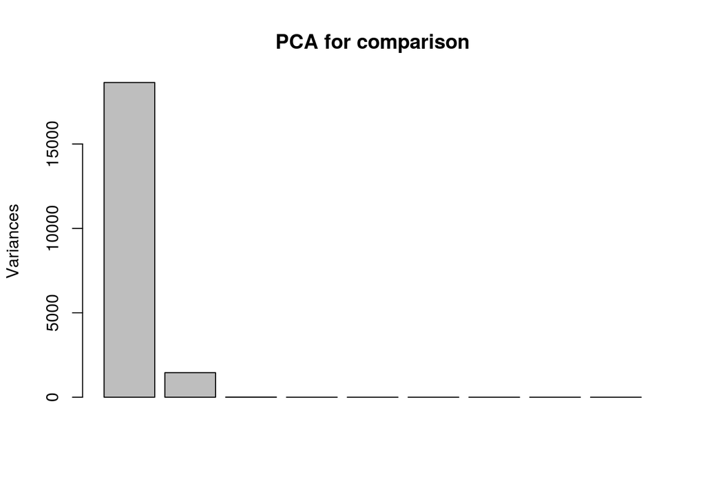

```r
## Performing reduction.
dim.reduct <- umap(mtcars[,-c(8,9)], n_neighbors = 15, min_dist = 0, metric = "euclidean", n_components = 2)
dim.reduct <-data.frame(dim.reduct, mtcars)

plot(prcomp(mtcars[,-c(8,9)], 2), main="PCA for comparison")
```

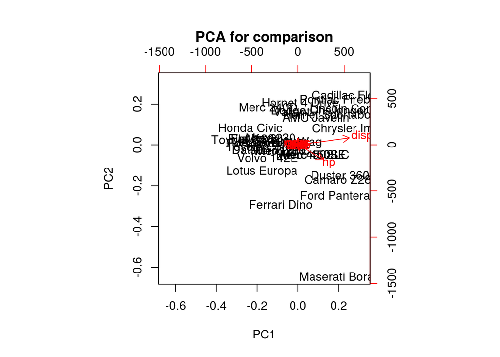

```r
biplot(prcomp(mtcars[,-c(8,9)], 2), main="PCA for comparison")
```

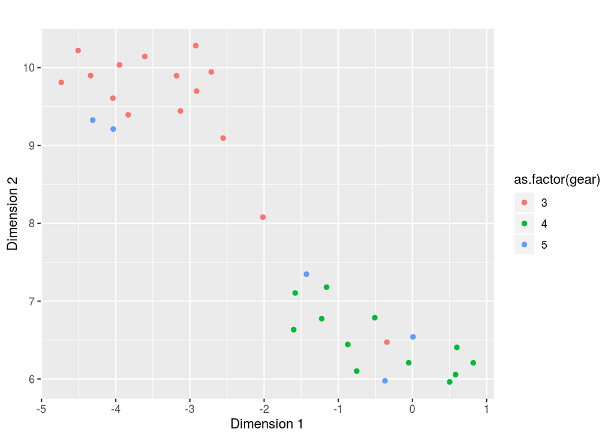

```r
ggplot(dim.reduct) +
  aes(x=X1, y=X2) +
  geom_point(aes(color=as.factor(gear))) +
  labs(title="", x="Dimension 1", y = "Dimension 2")
```

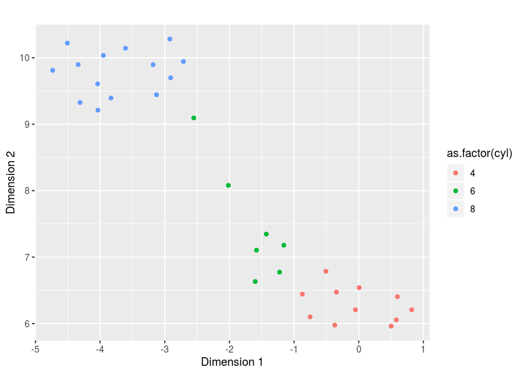

```r
ggplot(dim.reduct) +
  aes(x=X1, y=X2) +
  geom_point(aes(color=as.factor(cyl))) +
  labs(title="", x="Dimension 1", y = "Dimension 2")
```

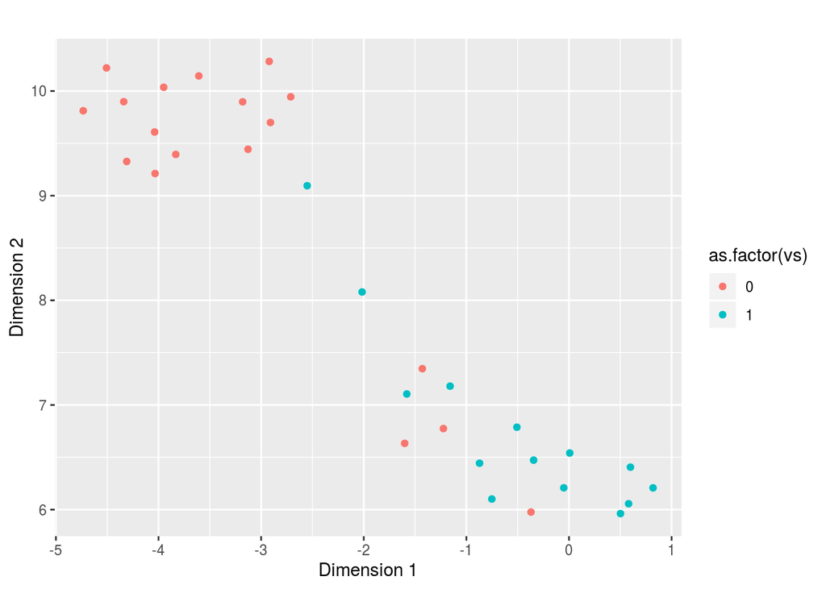

```r
ggplot(dim.reduct) +
  aes(x=X1, y=X2) +
  geom_point(aes(color=as.factor(vs))) +
  labs(title="", x="Dimension 1", y = "Dimension 2")
```

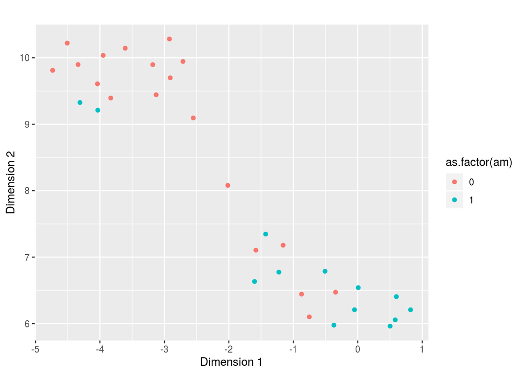

```r
ggplot(dim.reduct) +
  aes(x=X1, y=X2) +
  geom_point(aes(color=as.factor(am))) +
  labs(title="", x="Dimension 1", y = "Dimension 2")
```

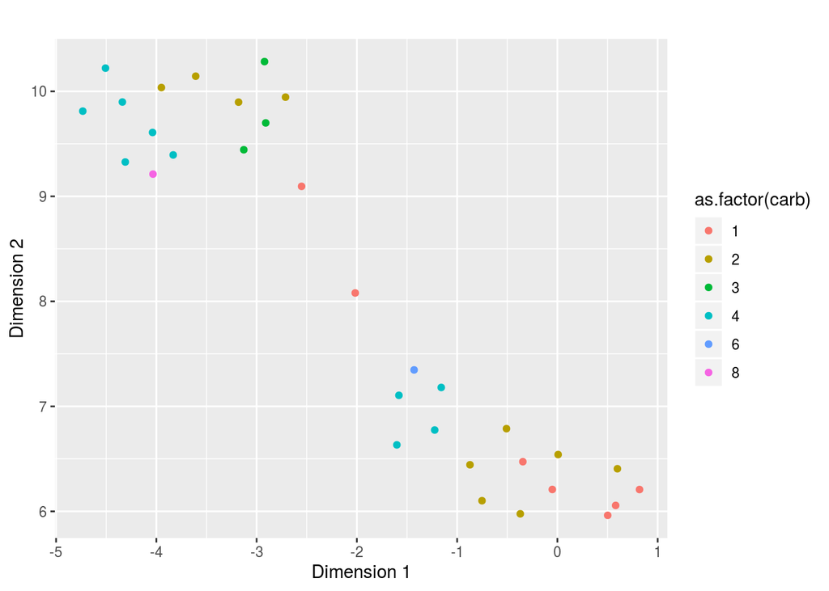

```r
ggplot(dim.reduct) +
  aes(x=X1, y=X2) +
  geom_point(aes(color=as.factor(carb))) +
  labs(title="", x="Dimension 1", y = "Dimension 2")
```

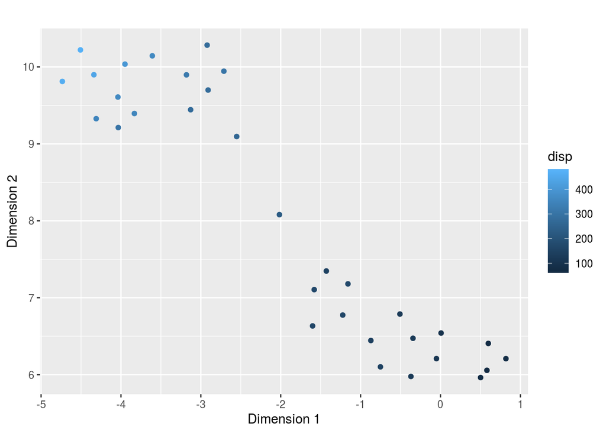

```r
ggplot(dim.reduct) +
  aes(x=X1, y=X2) +
  geom_point(aes(color=disp)) +
  labs(title="", x="Dimension 1", y = "Dimension 2")
```

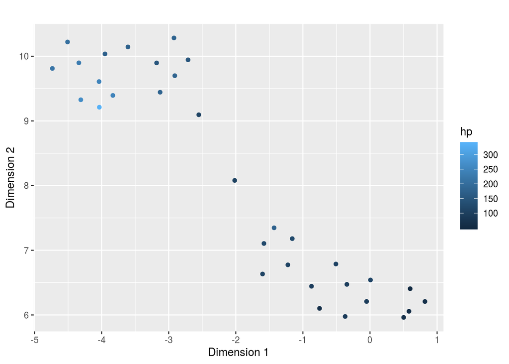

```r
ggplot(dim.reduct) +
  aes(x=X1, y=X2) +
  geom_point(aes(color=hp)) +
  labs(title="", x="Dimension 1", y = "Dimension 2")
```

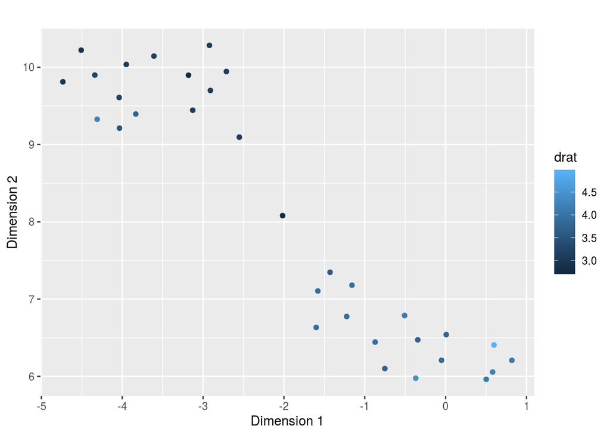

```r
ggplot(dim.reduct) +
  aes(x=X1, y=X2) +
  geom_point(aes(color=drat)) +
  labs(title="", x="Dimension 1", y = "Dimension 2")
```

## Exercise: What happens if you extract more dimensions than original variables?

Does it run? What does the plotted output look like?

## Exercise: Try changing the distance metric from ’euclidean’to something that doesn’t make sense for this data. Do you still get an output?

## Exercise: What happens as you change the minimum number of neighbors?

## Exercise Apply hdbscan to the output of UMAP.

## Exercise: try changing the minimum distance between poins in the embeding. Does hdbscan’s performance improve or declineas the distance increases/increases?

# Additional resources and further reading

- Automate the Boring Stuff with Python (applied intro to Python): https://automatetheboringstuff.com/
- Scikit-learn (general machine learning library): https://scikit-learn.org/stable/index.html
- Pandas (Python’s version of data.frames and other R-like structures): https://pandas.pydata.org/
  - 10 minute introduction: https://pandas.pydata.org/pandas-docs/stable/
- Keras (easy to use “deep learning” libray): https://keras.io/
  - Example workflow: https://pythonprogramming.net/introduction-deep-learning-python-tensorflow-keras/
- [R Interface to Python](https://rstudio.github.io/reticulate/)